# Aula 7 - Introdução à Econometria

Autor

João Ricardo F. de Lima

Data de Publicação

20 de julho de 2026

# Variáveis Qualitativas em Modelos de Regressão

Até o momento as variáveis independentes usadas nos modelos eram quantitativas. Contudo, em análise de regressão sempre serão encontradas variáveis de natureza qualitativa: gênero, raça, cor, religião, região geográfica, filiação partidária, etc.

Estas variáveis qualitativas não possuem um determinado valor numérico. Porém, podem ser quantificadas criando variáveis binárias (**dummies**) que assuem 2 valores, normalmente 0 e 1, se não possui ou se possui um determinado atributo.

**Exemplos:** **feminino=1 (feminino)** ou **=0 (masculino)**

**Nordeste=1 (Região Geográfica brasileira, Nordeste)** ou **=0 (caso contrário, ou seja, qualquer outra região brasileira)**

A primeira questão é definir qual evento será atribuído o valor 1 e qual será o valor zero. Em geral, o nome da variável indica qual evento tem valor 1. A categoria cujo valor é igual a zero é chamada de referência. As comparações são realizadas em relação à categoria de referência. Como as dummies assumem valores 0 e 1, não podem ser logaritmizadas. Se a amostra é muito pequena, deve-se ter cuidado ao incluir muitas variáveis dummy, pois cada uma custa 1 grau de liberdade.

## Exemplo de Base de Dados com variáveis dummy:

```r
library(wooldridge)
library(kableExtra)
library(dplyr)
# Carrega a base 'wage2'
data(wage1)

# Remove os valores ausentes (NAs)
sal <- na.omit(wage1)

# Cria um subgrupo
sal2 <- select(sal, wage, female, nonwhite, married, educ, exper)
kable(head(sal2, 10), align='cccccc', col.names = c("Salário", "Feminino", "Não Branco", "Casado", "Anos Escolaridade", "Anos Experiência")) %>%
  kable_styling(full_width=TRUE, position = "center")
```

| Salário | Feminino | Não Branco | Casado | Anos Escolaridade | Anos Experiência |
| --- | --- | --- | --- | --- | --- |
| 3.10 | 1 | 0 | 0 | 11 | 2 |
| 3.24 | 1 | 0 | 1 | 12 | 22 |
| 3.00 | 0 | 0 | 0 | 11 | 2 |
| 6.00 | 0 | 0 | 1 | 8 | 44 |
| 5.30 | 0 | 0 | 1 | 12 | 7 |
| 8.75 | 0 | 0 | 1 | 16 | 9 |
| 11.25 | 0 | 0 | 0 | 18 | 15 |
| 5.00 | 1 | 0 | 0 | 12 | 5 |
| 3.60 | 1 | 0 | 0 | 12 | 26 |
| 18.18 | 0 | 0 | 1 | 17 | 22 |

Considere a regressão:

$$wage=\mathbf{\hat \beta_0} + \mathbf{\hat \delta_0} female + \mathbf{\hat \beta_1}educ + u$$

Na equação anterior, o $\delta_0$ é a diferença no salario por hora entre mulheres e homens, dado o mesmo grau de educação. Assim, ele vai dizer se existe discriminação com as mulheres. Se $\delta_0$ for $< 0$, então, para o mesmo nível dos outros fatores, as mulheres ganham menos do que os homens, na média.

Graficamente, é como se houvesse um deslocamento de intercepto entre as linhas que representam homens e mulheres, como mostra o livro do Wooldridge (2017). Se o intercepto está incluído no modelo e se uma variável qualitativa tem **m** categorias, então, inserir apenas **m-1** variáveis *dummy*. Se não seguir esta regra, cairá na **armadilha da variável dummy**, que é um caso de correlação perfeita, dado que o intercepto é equivalente a um regressor cujo valor é uma constante = a 1.

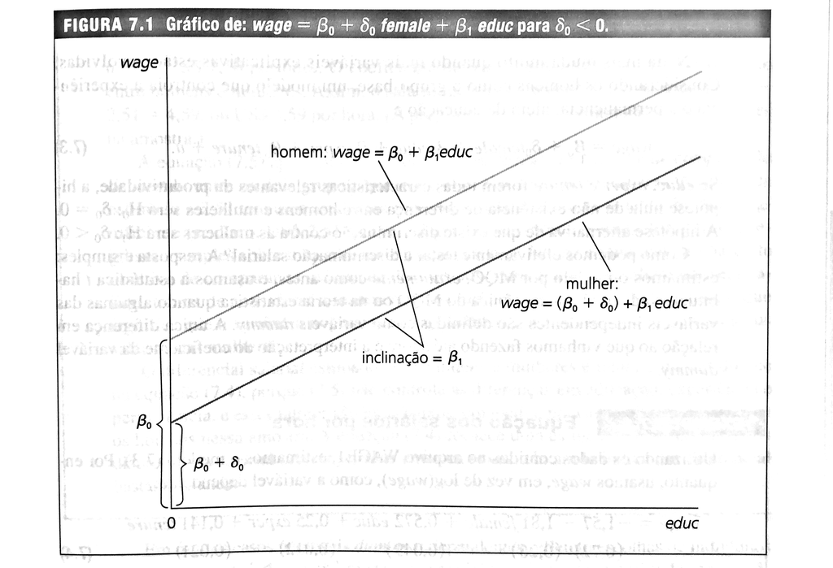

## Estimação do Modelo no R

```r
reg1 <- lm (wage ~ female + educ, data=sal2)
summary(reg1)
```

```
Call:
lm(formula = wage ~ female + educ, data = sal2)

Residuals:
    Min      1Q  Median      3Q     Max
-5.9890 -1.8702 -0.6651  1.0447 15.4998

Coefficients:
            Estimate Std. Error t value Pr(>|t|)
(Intercept)  0.62282    0.67253   0.926    0.355
female      -2.27336    0.27904  -8.147 2.76e-15 ***
educ         0.50645    0.05039  10.051  < 2e-16 ***
---
Signif. codes:  0 '***' 0.001 '**' 0.01 '*' 0.05 '.' 0.1 ' ' 1

Residual standard error: 3.186 on 523 degrees of freedom
Multiple R-squared:  0.2588,    Adjusted R-squared:  0.256
F-statistic: 91.32 on 2 and 523 DF,  p-value: < 2.2e-16
```

Assim, o valor de -2,27336 é a diferença no salário por hora entre mulheres e homens, dado o mesmo grau de educação. Como o valor é negativo, as mulheres ganham US$ 2,27 dólares a menos do que os homens. A regressão, então, tem um intercepto para os homens, igual a US$ 0,62 e o outro seria das mulheres, igual a US$ 0,62 - US$ 2,27= - US$1,65.

```r
reg2 <- lm (wage ~ female + nonwhite + married + educ + exper, data=sal2)
summary(reg2)
```

```
Call:
lm(formula = wage ~ female + nonwhite + married + educ + exper,
    data = sal2)

Residuals:
    Min      1Q  Median      3Q     Max
-6.4069 -1.9069 -0.5999  1.1658 14.6520

Coefficients:
            Estimate Std. Error t value Pr(>|t|)
(Intercept) -1.78458    0.75951  -2.350   0.0192 *
female      -2.06753    0.27257  -7.585 1.54e-13 ***
nonwhite    -0.02519    0.44343  -0.057   0.9547
married      0.65923    0.29767   2.215   0.0272 *
educ         0.58310    0.05185  11.246  < 2e-16 ***
exper        0.05567    0.01107   5.031 6.74e-07 ***
---
Signif. codes:  0 '***' 0.001 '**' 0.01 '*' 0.05 '.' 0.1 ' ' 1

Residual standard error: 3.069 on 520 degrees of freedom
Multiple R-squared:  0.3158,    Adjusted R-squared:  0.3092
F-statistic:    48 on 5 and 520 DF,  p-value: < 2.2e-16
```

O salário médio/hora de uma mulher é 2,07 dólares menor em comparação com os homens, para a mesma raça, ser casado, anos de educação e experiência. O salário dos não brancos é cerca de 0,02 dólares menor do que os dos trabalhadores brancos (contudo, não foi estatisticamente significativo). O salário dos casados é aproximadamente 0,66 dólares maior do que o salário dos não casados.

```r
sal2$educ[sal2$educ == 0] <- 0.000001
reg3 <- lm (log(wage) ~ female + exper + log(educ), data=sal2)
summary(reg3)
```

```
Call:
lm(formula = log(wage) ~ female + exper + log(educ), data = sal2)

Residuals:
     Min       1Q   Median       3Q      Max
-1.99846 -0.30076 -0.05806  0.34363  1.66178

Coefficients:
             Estimate Std. Error t value Pr(>|t|)
(Intercept)  1.571681   0.069233  22.701  < 2e-16 ***
female      -0.383016   0.042684  -8.973  < 2e-16 ***
exper        0.004475   0.001585   2.823  0.00493 **
log(educ)    0.064989   0.020798   3.125  0.00188 **
---
Signif. codes:  0 '***' 0.001 '**' 0.01 '*' 0.05 '.' 0.1 ' ' 1

Residual standard error: 0.4873 on 522 degrees of freedom
Multiple R-squared:  0.1645,    Adjusted R-squared:  0.1597
F-statistic: 34.25 on 3 and 522 DF,  p-value: < 2.2e-16
```

No caso acima, wage está em log. Assim, a interpretação é que as mulheres ganham cerca de 38,3% a menos do que os homens, para o mesmo nível de educação e experiência.

## Estimação do Modelo no Python

```python
#Pacotes a serem utilizados
import wooldridge
import pandas as pd
import numpy as np
import matplotlib.pyplot as plt
import seaborn as sns
import statsmodels.formula.api as smf

#Carregar dados no computador
wage1 = wooldridge.data('wage1')

#Observar a estrutura dos dados
wooldridge.data('wage1', description=True)
```

```
name of dataset: wage1
no of variables: 24
no of observations: 526

+----------+---------------------------------+
| variable | label                           |
+----------+---------------------------------+
| wage     | average hourly earnings         |
| educ     | years of education              |
| exper    | years potential experience      |
| tenure   | years with current employer     |
| nonwhite | =1 if nonwhite                  |
| female   | =1 if female                    |
| married  | =1 if married                   |
| numdep   | number of dependents            |
| smsa     | =1 if live in SMSA              |
| northcen | =1 if live in north central U.S |
| south    | =1 if live in southern region   |
| west     | =1 if live in western region    |
| construc | =1 if work in construc. indus.  |
| ndurman  | =1 if in nondur. manuf. indus.  |
| trcommpu | =1 if in trans, commun, pub ut  |
| trade    | =1 if in wholesale or retail    |
| services | =1 if in services indus.        |
| profserv | =1 if in prof. serv. indus.     |
| profocc  | =1 if in profess. occupation    |
| clerocc  | =1 if in clerical occupation    |
| servocc  | =1 if in service occupation     |
| lwage    | log(wage)                       |
| expersq  | exper^2                         |
| tenursq  | tenure^2                        |
+----------+---------------------------------+

These are data from the 1976 Current Population Survey, collected by
Henry Farber when he and I were colleagues at MIT in 1988.
```

```python
wage1.isna().sum()
```

```
wage        0
educ        0
exper       0
tenure      0
nonwhite    0
female      0
married     0
numdep      0
smsa        0
northcen    0
south       0
west        0
construc    0
ndurman     0
trcommpu    0
trade       0
services    0
profserv    0
profocc     0
clerocc     0
servocc     0
lwage       0
expersq     0
tenursq     0
dtype: int64
```

```python
sal = wage1.dropna()

# Cria um subgrupo

sal2 = sal[["wage", "female", "nonwhite", "married", "educ", "exper"]]

sal2.describe()
```

```
             wage      female    nonwhite     married        educ      exper
count  526.000000  526.000000  526.000000  526.000000  526.000000  526.00000
mean     5.896103    0.479087    0.102662    0.608365   12.562738   17.01711
std      3.693086    0.500038    0.303805    0.488580    2.769022   13.57216
min      0.530000    0.000000    0.000000    0.000000    0.000000    1.00000
25%      3.330000    0.000000    0.000000    0.000000   12.000000    5.00000
50%      4.650000    0.000000    0.000000    1.000000   12.000000   13.50000
75%      6.880000    1.000000    0.000000    1.000000   14.000000   26.00000
max     24.980000    1.000000    1.000000    1.000000   18.000000   51.00000
```

```python
sal2.head
```

```
<bound method NDFrame.head of       wage  female  nonwhite  married  educ  exper
0     3.10       1         0        0    11      2
1     3.24       1         0        1    12     22
2     3.00       0         0        0    11      2
3     6.00       0         0        1     8     44
4     5.30       0         0        1    12      7
..     ...     ...       ...      ...   ...    ...
521  15.00       1         0        1    16     14
522   2.27       1         0        0    10      2
523   4.67       0         0        1    15     13
524  11.56       0         0        1    16      5
525   3.50       1         1        0    14      5

[526 rows x 6 columns]>
```

```python
sal2.tail
```

```
<bound method NDFrame.tail of       wage  female  nonwhite  married  educ  exper
0     3.10       1         0        0    11      2
1     3.24       1         0        1    12     22
2     3.00       0         0        0    11      2
3     6.00       0         0        1     8     44
4     5.30       0         0        1    12      7
..     ...     ...       ...      ...   ...    ...
521  15.00       1         0        1    16     14
522   2.27       1         0        0    10      2
523   4.67       0         0        1    15     13
524  11.56       0         0        1    16      5
525   3.50       1         1        0    14      5

[526 rows x 6 columns]>
```

```python
reg1 = smf.ols('wage ~ female + educ', data=sal2)
result1 = reg1.fit()
print(result1.summary())
```

```
                            OLS Regression Results
==============================================================================
Dep. Variable:                   wage   R-squared:                       0.259
Model:                            OLS   Adj. R-squared:                  0.256
Method:                 Least Squares   F-statistic:                     91.32
Date:                seg, 20 jul 2026   Prob (F-statistic):           9.66e-35
Time:                        09:44:46   Log-Likelihood:                -1354.3
No. Observations:                 526   AIC:                             2715.
Df Residuals:                     523   BIC:                             2727.
Df Model:                           2
Covariance Type:            nonrobust
==============================================================================
                 coef    std err          t      P>|t|      [0.025      0.975]
------------------------------------------------------------------------------
Intercept      0.6228      0.673      0.926      0.355      -0.698       1.944
female        -2.2734      0.279     -8.147      0.000      -2.822      -1.725
educ           0.5065      0.050     10.051      0.000       0.407       0.605
==============================================================================
Omnibus:                      205.985   Durbin-Watson:                   1.830
Prob(Omnibus):                  0.000   Jarque-Bera (JB):              819.498
Skew:                           1.772   Prob(JB):                    1.12e-178
Kurtosis:                       7.984   Cond. No.                         63.2
==============================================================================

Notes:
[1] Standard Errors assume that the covariance matrix of the errors is correctly specified.
```

```python
reg2 = smf.ols('wage ~ female + nonwhite + married + educ + exper', data=sal2)
result2 = reg2.fit()
print(result2.summary())
```

```
                            OLS Regression Results
==============================================================================
Dep. Variable:                   wage   R-squared:                       0.316
Model:                            OLS   Adj. R-squared:                  0.309
Method:                 Least Squares   F-statistic:                     48.00
Date:                seg, 20 jul 2026   Prob (F-statistic):           8.01e-41
Time:                        09:44:46   Log-Likelihood:                -1333.2
No. Observations:                 526   AIC:                             2678.
Df Residuals:                     520   BIC:                             2704.
Df Model:                           5
Covariance Type:            nonrobust
==============================================================================
                 coef    std err          t      P>|t|      [0.025      0.975]
------------------------------------------------------------------------------
Intercept     -1.7846      0.760     -2.350      0.019      -3.277      -0.293
female        -2.0675      0.273     -7.585      0.000      -2.603      -1.532
nonwhite      -0.0252      0.443     -0.057      0.955      -0.896       0.846
married        0.6592      0.298      2.215      0.027       0.074       1.244
educ           0.5831      0.052     11.246      0.000       0.481       0.685
exper          0.0557      0.011      5.031      0.000       0.034       0.077
==============================================================================
Omnibus:                      201.710   Durbin-Watson:                   1.807
Prob(Omnibus):                  0.000   Jarque-Bera (JB):              804.697
Skew:                           1.728   Prob(JB):                    1.83e-175
Kurtosis:                       7.977   Cond. No.                         138.
==============================================================================

Notes:
[1] Standard Errors assume that the covariance matrix of the errors is correctly specified.
```

```python
sal2['educ'] = sal2['educ'].replace(0, 0.000001)
reg3 = smf.ols('np.log(wage) ~ female + exper + np.log(educ)', data=sal2)
result3 = reg3.fit()
print(result3.summary())
```

```
                            OLS Regression Results
==============================================================================
Dep. Variable:           np.log(wage)   R-squared:                       0.164
Model:                            OLS   Adj. R-squared:                  0.160
Method:                 Least Squares   F-statistic:                     34.25
Date:                seg, 20 jul 2026   Prob (F-statistic):           3.21e-20
Time:                        09:44:46   Log-Likelihood:                -366.18
No. Observations:                 526   AIC:                             740.4
Df Residuals:                     522   BIC:                             757.4
Df Model:                           3
Covariance Type:            nonrobust
================================================================================
                   coef    std err          t      P>|t|      [0.025      0.975]
--------------------------------------------------------------------------------
Intercept        1.5717      0.069     22.701      0.000       1.436       1.708
female          -0.3830      0.043     -8.973      0.000      -0.467      -0.299
exper            0.0045      0.002      2.823      0.005       0.001       0.008
np.log(educ)     0.0650      0.021      3.125      0.002       0.024       0.106
==============================================================================
Omnibus:                       11.368   Durbin-Watson:                   1.828
Prob(Omnibus):                  0.003   Jarque-Bera (JB):               12.886
Skew:                           0.272   Prob(JB):                      0.00159
Kurtosis:                       3.540   Cond. No.                         75.7
==============================================================================

Notes:
[1] Standard Errors assume that the covariance matrix of the errors is correctly specified.
```

# Informações Ordinais

```r
# Exemplo considerando apenas os homens na base de dados

data('beauty')

beautyM<-filter(beauty, female == '0')
reg4 <- lm(lwage~belavg+abvavg+educ+exper+married+black+union, data=beautyM)
summary(reg4)
```

```
Call:
lm(formula = lwage ~ belavg + abvavg + educ + exper + married +
    black + union, data = beautyM)

Residuals:
     Min       1Q   Median       3Q      Max
-1.43951 -0.28663 -0.01136  0.27682  1.91522

Coefficients:
             Estimate Std. Error t value Pr(>|t|)
(Intercept)  0.640971   0.101952   6.287 5.27e-10 ***
belavg      -0.164838   0.054028  -3.051 0.002355 **
abvavg      -0.021349   0.038507  -0.554 0.579445
educ         0.066203   0.006634   9.980  < 2e-16 ***
exper        0.013506   0.001484   9.103  < 2e-16 ***
married      0.118198   0.044020   2.685 0.007398 **
black       -0.286934   0.077094  -3.722 0.000211 ***
union        0.155716   0.036937   4.216 2.77e-05 ***
---
Signif. codes:  0 '***' 0.001 '**' 0.01 '*' 0.05 '.' 0.1 ' ' 1

Residual standard error: 0.4791 on 816 degrees of freedom
Multiple R-squared:   0.22, Adjusted R-squared:  0.2133
F-statistic: 32.87 on 7 and 816 DF,  p-value: < 2.2e-16
```

Uma regressão apenas com dados de homens indica que aqueles com aparência abaixo da média ganham 16,48% a menos do que aqueles com aparência média e tudo o mais igual.

```r
# Exemplo considerando apenas as mulheres na base de dados

beautyF<-filter(beauty, female == '1')
reg5 <- lm(lwage~belavg+abvavg+educ+exper+married+black+union, data=beautyF)
summary(reg5)
```

```
Call:
lm(formula = lwage ~ belavg + abvavg + educ + exper + married +
    black + union, data = beautyF)

Residuals:
     Min       1Q   Median       3Q      Max
-1.17135 -0.28511  0.04895  0.29681  2.67704

Coefficients:
             Estimate Std. Error t value Pr(>|t|)
(Intercept)  0.075040   0.125575   0.598   0.5504
belavg      -0.093467   0.066372  -1.408   0.1598
abvavg       0.068007   0.049367   1.378   0.1691
educ         0.081082   0.008773   9.242  < 2e-16 ***
exper        0.009766   0.002145   4.553 6.90e-06 ***
married     -0.045382   0.043973  -1.032   0.3026
black        0.134152   0.069321   1.935   0.0536 .
union        0.302297   0.054060   5.592 4.01e-08 ***
---
Signif. codes:  0 '***' 0.001 '**' 0.01 '*' 0.05 '.' 0.1 ' ' 1

Residual standard error: 0.4541 on 428 degrees of freedom
Multiple R-squared:  0.262, Adjusted R-squared:  0.2499
F-statistic: 21.71 on 7 and 428 DF,  p-value: < 2.2e-16
```

Uma regressão apenas com dados de mulheres indica que aqueles com aparência abaixo da média ganham 9,34% a menos do que aqueles com aparência média e tudo o mais igual.

```r
# Exemplo considerando todos na base de dados

reg6 <- lm(lwage~belavg+abvavg+educ+exper+married+black+union, data=beauty)
summary(reg6)
```

```
Call:
lm(formula = lwage ~ belavg + abvavg + educ + exper + married +
    black + union, data = beauty)

Residuals:
     Min       1Q   Median       3Q      Max
-1.65838 -0.30120  0.00832  0.31356  2.69493

Coefficients:
             Estimate Std. Error t value Pr(>|t|)
(Intercept)  0.269568   0.084817   3.178 0.001518 **
belavg      -0.158247   0.045578  -3.472 0.000534 ***
abvavg       0.006455   0.033032   0.195 0.845110
educ         0.075309   0.005715  13.177  < 2e-16 ***
exper        0.016171   0.001282  12.612  < 2e-16 ***
married      0.164415   0.032676   5.032 5.57e-07 ***
black       -0.136876   0.056399  -2.427 0.015369 *
union        0.230066   0.032804   7.013 3.80e-12 ***
---
Signif. codes:  0 '***' 0.001 '**' 0.01 '*' 0.05 '.' 0.1 ' ' 1

Residual standard error: 0.5122 on 1252 degrees of freedom
Multiple R-squared:  0.2618,    Adjusted R-squared:  0.2576
F-statistic: 63.42 on 7 and 1252 DF,  p-value: < 2.2e-16
```

Uma regressão com todos os dados indica que aqueles com aparência abaixo da média ganham 15,82% a menos do que aqueles com aparência média e tudo o mais igual.

## Estimação do Modelo no Python

```python
#Pacotes a serem utilizados
import wooldridge
import pandas as pd
import numpy as np
import matplotlib.pyplot as plt
import seaborn as sns
import statsmodels.formula.api as smf

#Carregar dados no computador
beauty = wooldridge.data('beauty')

#Observar a estrutura dos dados
wooldridge.data('beauty', description=True)
```

```
name of dataset: beauty
no of variables: 17
no of observations: 1260

+----------+-------------------------------+
| variable | label                         |
+----------+-------------------------------+
| wage     | hourly wage                   |
| lwage    | log(wage)                     |
| belavg   | =1 if looks <= 2              |
| abvavg   | =1 if looks >=4               |
| exper    | years of workforce experience |
| looks    | from 1 to 5                   |
| union    | =1 if union member            |
| goodhlth | =1 if good health             |
| black    | =1 if black                   |
| female   | =1 if female                  |
| married  | =1 if married                 |
| south    | =1 if live in south           |
| bigcity  | =1 if live in big city        |
| smllcity | =1 if live in small city      |
| service  | =1 if service industry        |
| expersq  | exper^2                       |
| educ     | years of schooling            |
+----------+-------------------------------+

Hamermesh, D.S. and J.E. Biddle (1994), “Beauty and the Labor Market,”
American Economic Review 84, 1174-1194. Professor Hamermesh kindly
provided me with the data. For manageability, I have included only a
subset of the variables, which results in somewhat larger sample sizes
than reported for the regressions in the Hamermesh and Biddle paper.
```

```python
# Cria um subgrupo só com os homens
beautyM = beauty.query("female == 0")

reg4 = smf.ols('lwage ~ belavg + abvavg + educ + exper + married + black + union', data=beautyM)
result4 = reg4.fit()
print(result4.summary())
```

```
                            OLS Regression Results
==============================================================================
Dep. Variable:                  lwage   R-squared:                       0.220
Model:                            OLS   Adj. R-squared:                  0.213
Method:                 Least Squares   F-statistic:                     32.87
Date:                seg, 20 jul 2026   Prob (F-statistic):           2.29e-40
Time:                        09:44:46   Log-Likelihood:                -558.93
No. Observations:                 824   AIC:                             1134.
Df Residuals:                     816   BIC:                             1172.
Df Model:                           7
Covariance Type:            nonrobust
==============================================================================
                 coef    std err          t      P>|t|      [0.025      0.975]
------------------------------------------------------------------------------
Intercept      0.6410      0.102      6.287      0.000       0.441       0.841
belavg        -0.1648      0.054     -3.051      0.002      -0.271      -0.059
abvavg        -0.0213      0.039     -0.554      0.579      -0.097       0.054
educ           0.0662      0.007      9.980      0.000       0.053       0.079
exper          0.0135      0.001      9.103      0.000       0.011       0.016
married        0.1182      0.044      2.685      0.007       0.032       0.205
black         -0.2869      0.077     -3.722      0.000      -0.438      -0.136
union          0.1557      0.037      4.216      0.000       0.083       0.228
==============================================================================
Omnibus:                       25.932   Durbin-Watson:                   1.778
Prob(Omnibus):                  0.000   Jarque-Bera (JB):               43.459
Skew:                           0.241   Prob(JB):                     3.66e-10
Kurtosis:                       4.016   Cond. No.                         166.
==============================================================================

Notes:
[1] Standard Errors assume that the covariance matrix of the errors is correctly specified.
```

```python
# Cria um subgrupo só com as mulheres
beautyF = beauty.query("female == 1")

reg5 = smf.ols('lwage ~ belavg + abvavg + educ + exper + married + black + union', data=beautyF)
result5 = reg5.fit()
print(result5.summary())
```

```
                            OLS Regression Results
==============================================================================
Dep. Variable:                  lwage   R-squared:                       0.262
Model:                            OLS   Adj. R-squared:                  0.250
Method:                 Least Squares   F-statistic:                     21.71
Date:                seg, 20 jul 2026   Prob (F-statistic):           4.35e-25
Time:                        09:44:46   Log-Likelihood:                -270.47
No. Observations:                 436   AIC:                             556.9
Df Residuals:                     428   BIC:                             589.6
Df Model:                           7
Covariance Type:            nonrobust
==============================================================================
                 coef    std err          t      P>|t|      [0.025      0.975]
------------------------------------------------------------------------------
Intercept      0.0750      0.126      0.598      0.550      -0.172       0.322
belavg        -0.0935      0.066     -1.408      0.160      -0.224       0.037
abvavg         0.0680      0.049      1.378      0.169      -0.029       0.165
educ           0.0811      0.009      9.242      0.000       0.064       0.098
exper          0.0098      0.002      4.553      0.000       0.006       0.014
married       -0.0454      0.044     -1.032      0.303      -0.132       0.041
black          0.1342      0.069      1.935      0.054      -0.002       0.270
union          0.3023      0.054      5.592      0.000       0.196       0.409
==============================================================================
Omnibus:                       29.521   Durbin-Watson:                   1.849
Prob(Omnibus):                  0.000   Jarque-Bera (JB):               94.131
Skew:                           0.193   Prob(JB):                     3.63e-21
Kurtosis:                       5.243   Cond. No.                         122.
==============================================================================

Notes:
[1] Standard Errors assume that the covariance matrix of the errors is correctly specified.
```

```python
#Usando toda a base de dados
reg6 = smf.ols('lwage ~ belavg + abvavg + educ + exper + married + black + union', data=beauty)
result6 = reg6.fit()
print(result6.summary())
```

```
                            OLS Regression Results
==============================================================================
Dep. Variable:                  lwage   R-squared:                       0.262
Model:                            OLS   Adj. R-squared:                  0.258
Method:                 Least Squares   F-statistic:                     63.42
Date:                seg, 20 jul 2026   Prob (F-statistic):           3.27e-78
Time:                        09:44:46   Log-Likelihood:                -940.94
No. Observations:                1260   AIC:                             1898.
Df Residuals:                    1252   BIC:                             1939.
Df Model:                           7
Covariance Type:            nonrobust
==============================================================================
                 coef    std err          t      P>|t|      [0.025      0.975]
------------------------------------------------------------------------------
Intercept      0.2696      0.085      3.178      0.002       0.103       0.436
belavg        -0.1582      0.046     -3.472      0.001      -0.248      -0.069
abvavg         0.0065      0.033      0.195      0.845      -0.058       0.071
educ           0.0753      0.006     13.177      0.000       0.064       0.087
exper          0.0162      0.001     12.612      0.000       0.014       0.019
married        0.1644      0.033      5.032      0.000       0.100       0.229
black         -0.1369      0.056     -2.427      0.015      -0.248      -0.026
union          0.2301      0.033      7.013      0.000       0.166       0.294
==============================================================================
Omnibus:                       43.274   Durbin-Watson:                   1.710
Prob(Omnibus):                  0.000   Jarque-Bera (JB):               92.859
Skew:                           0.186   Prob(JB):                     6.85e-21
Kurtosis:                       4.277   Cond. No.                         147.
==============================================================================

Notes:
[1] Standard Errors assume that the covariance matrix of the errors is correctly specified.
```

# Uso de dummies interativas

O uso de dummies de interação considera 2 ou mais variáveis categóricas. No Exemplo, tem-se a variável de interação mulheres x não brancas para se analisar as diferenças com mulheres, trabalhadores não brancos e homens brancos. É o que se denomina de dummy de intercepto pois gera mudanças no intercepto.

Para mulher, o $\hat \beta$ é igual a -2,79 dólares por hora (wage não está logaritmizado, ou seja, é modelo lin-lin); Para cor preto o $\hat \beta$ é igual a -1,84 dólares por hora; Considerando ambos, é igual a:

$$-2,79-1,84+3,58=-1,05$$
Ser mulher e preta, o salário é US$1,05 menor do que os dos homens e brancos.

```r
#Regressão Quadro - Modelo Log-Lin
reg7 <- lm(wage ~ female + black + union + educ + exper + female*black, data=beauty)
summary(reg7)
```

```
Call:
lm(formula = wage ~ female + black + union + educ + exper + female *
    black, data = beauty)

Residuals:
   Min     1Q Median     3Q    Max
-6.966 -2.107 -0.572  1.083 71.468

Coefficients:
             Estimate Std. Error t value Pr(>|t|)
(Intercept)  -0.24986    0.68091  -0.367  0.71372
female       -2.79466    0.26802 -10.427  < 2e-16 ***
black        -1.83687    0.65899  -2.787  0.00539 **
union         0.82210    0.26721   3.077  0.00214 **
educ          0.45991    0.04622   9.951  < 2e-16 ***
exper         0.08322    0.01034   8.046 1.97e-15 ***
female:black  3.58394    0.90665   3.953 8.15e-05 ***
---
Signif. codes:  0 '***' 0.001 '**' 0.01 '*' 0.05 '.' 0.1 ' ' 1

Residual standard error: 4.171 on 1253 degrees of freedom
Multiple R-squared:  0.2027,    Adjusted R-squared:  0.1989
F-statistic: 53.11 on 6 and 1253 DF,  p-value: < 2.2e-16
```

É possível analisar também mudanças no coeficiente de inclinação!

Considere o modelo log-lin estimado:

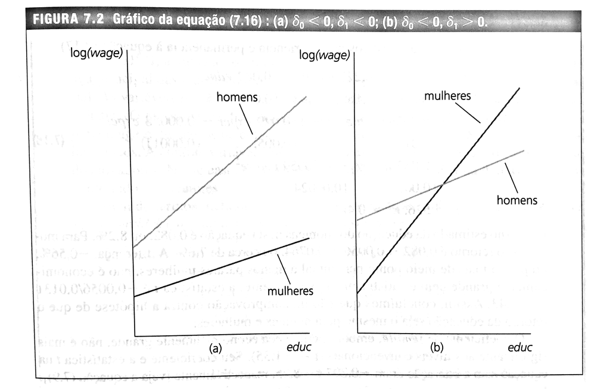

Dummies de Inclinação

```r
#Regressão Quadro - Modelo Log-Lin Dummy de inclinação
reg8 <- lm(lwage ~ female + black + union + educ + exper + female*educ + female*black + union*exper, data=beauty)
summary(reg8)
```

```
Call:
lm(formula = lwage ~ female + black + union + educ + exper +
    female * educ + female * black + union * exper, data = beauty)

Residuals:
     Min       1Q   Median       3Q      Max
-1.40843 -0.28726  0.00653  0.28393  2.76758

Coefficients:
              Estimate Std. Error t value Pr(>|t|)
(Intercept)   0.674580   0.091729   7.354 3.47e-13 ***
female       -0.719417   0.144492  -4.979 7.29e-07 ***
black        -0.307397   0.075263  -4.084 4.70e-05 ***
union         0.293201   0.057221   5.124 3.46e-07 ***
educ          0.066679   0.006453  10.334  < 2e-16 ***
exper         0.014486   0.001369  10.578  < 2e-16 ***
female:educ   0.019111   0.011078   1.725   0.0847 .
female:black  0.442454   0.104128   4.249 2.31e-05 ***
union:exper  -0.004837   0.002517  -1.922   0.0549 .
---
Signif. codes:  0 '***' 0.001 '**' 0.01 '*' 0.05 '.' 0.1 ' ' 1

Residual standard error: 0.4746 on 1251 degrees of freedom
Multiple R-squared:  0.3668,    Adjusted R-squared:  0.3627
F-statistic: 90.57 on 8 and 1251 DF,  p-value: < 2.2e-16
```

O retorno da educação para os homens é de 6,67%, aproximadamente. Para as mulheres é 0,066679+0,019111=0,08579 ou 8,58%. A diferença a mais para as mulheres é significativo estatisticamente a 10% de probabilidade.

O coeficiente female foi estatisticamente significativo e negativo, indicando que as mulheres ganham menos do que os homens.

## Estimação do Modelo no Python

```python
#Pacotes a serem utilizados
import wooldridge
import pandas as pd
import numpy as np
import matplotlib.pyplot as plt
import seaborn as sns
import statsmodels.formula.api as smf

#Carregar dados no computador
beauty = wooldridge.data('beauty')

#Usando toda a base de dados
reg7 = smf.ols('wage ~ female + black + union + educ + exper + female:black', data=beauty)
result7 = reg7.fit()
print(result7.summary())
```

```
                            OLS Regression Results
==============================================================================
Dep. Variable:                   wage   R-squared:                       0.203
Model:                            OLS   Adj. R-squared:                  0.199
Method:                 Least Squares   F-statistic:                     53.11
Date:                seg, 20 jul 2026   Prob (F-statistic):           1.84e-58
Time:                        09:44:47   Log-Likelihood:                -3583.9
No. Observations:                1260   AIC:                             7182.
Df Residuals:                    1253   BIC:                             7218.
Df Model:                           6
Covariance Type:            nonrobust
================================================================================
                   coef    std err          t      P>|t|      [0.025      0.975]
--------------------------------------------------------------------------------
Intercept       -0.2499      0.681     -0.367      0.714      -1.586       1.086
female          -2.7947      0.268    -10.427      0.000      -3.320      -2.269
black           -1.8369      0.659     -2.787      0.005      -3.130      -0.544
union            0.8221      0.267      3.077      0.002       0.298       1.346
educ             0.4599      0.046      9.951      0.000       0.369       0.551
exper            0.0832      0.010      8.046      0.000       0.063       0.104
female:black     3.5839      0.907      3.953      0.000       1.805       5.363
==============================================================================
Omnibus:                     1538.111   Durbin-Watson:                   1.882
Prob(Omnibus):                  0.000   Jarque-Bera (JB):           327656.529
Skew:                           6.050   Prob(JB):                         0.00
Kurtosis:                      81.068   Cond. No.                         218.
==============================================================================

Notes:
[1] Standard Errors assume that the covariance matrix of the errors is correctly specified.
```

```python
reg8 = smf.ols('lwage ~ female + black + union + educ + exper + female:educ + female:black + union:exper', data=beauty)
result8 = reg8.fit()
print(result8.summary())
```

```
                            OLS Regression Results
==============================================================================
Dep. Variable:                  lwage   R-squared:                       0.367
Model:                            OLS   Adj. R-squared:                  0.363
Method:                 Least Squares   F-statistic:                     90.57
Date:                seg, 20 jul 2026   Prob (F-statistic):          1.57e-118
Time:                        09:44:47   Log-Likelihood:                -844.29
No. Observations:                1260   AIC:                             1707.
Df Residuals:                    1251   BIC:                             1753.
Df Model:                           8
Covariance Type:            nonrobust
================================================================================
                   coef    std err          t      P>|t|      [0.025      0.975]
--------------------------------------------------------------------------------
Intercept        0.6746      0.092      7.354      0.000       0.495       0.855
female          -0.7194      0.144     -4.979      0.000      -1.003      -0.436
black           -0.3074      0.075     -4.084      0.000      -0.455      -0.160
union            0.2932      0.057      5.124      0.000       0.181       0.405
educ             0.0667      0.006     10.334      0.000       0.054       0.079
exper            0.0145      0.001     10.578      0.000       0.012       0.017
female:educ      0.0191      0.011      1.725      0.085      -0.003       0.041
female:black     0.4425      0.104      4.249      0.000       0.238       0.647
union:exper     -0.0048      0.003     -1.922      0.055      -0.010       0.000
==============================================================================
Omnibus:                       55.391   Durbin-Watson:                   1.828
Prob(Omnibus):                  0.000   Jarque-Bera (JB):              131.533
Skew:                           0.227   Prob(JB):                     2.74e-29
Kurtosis:                       4.516   Cond. No.                         306.
==============================================================================

Notes:
[1] Standard Errors assume that the covariance matrix of the errors is correctly specified.
```

# O uso de Dummies para quebras de séries

Existe um teste, chamado de **Teste de Chow**, para verificar se dois períodos de tempo ou dois grupos seguem a mesma função de regressão.

Se houver diferença (quebra estrutural), os valores dos parâmetros do modelo não permanecem o mesmo durante todo o período.

Assim, normalmente, são estimados três modelos, sendo um com todos os dados, outro com uma parte dele (representa um grupo ou uma parte da série temporal) e, finalmente, um último modelo (com os dados do outro grupo ou da outra parte da série temporal).

A regressão com todos os dados gera uma soma de quadrados do resíduo chamada soma de quadrados restrita (SQRr). As outras duas regressões também geram somas de quadrados (SQR1 e SQR2).

A soma de SQR1 e SQR2 é chamada de Soma de Quadrados Irrestrito (SQRi). Com estes valores é possível fazer um teste F como abaixo.

$$F=\frac{(SQRr-SQRi)/k}{(SQRi)/(n_1+n_2-2k)} \sim F_{[k,(n_1+n_2-2k)]}$$
A **Hipótese Nula** do Teste é *ausência de quebra estrutural*, ou seja, as regressões antes e depois de uma data determinada são iguais.

Uma outra possibilidade é gerar uma variável dummy que vai assumir o valor 0 para um determinado grupo ou parte da série temporal e valor 1 para o outro grupo ou parte da série temporal. Fazer a estimação do modelo e incluir a variável dummy de intercepto e de inclinação e checar as significâncias. Se forem significativas, indica que existem diferenças. A diferença pode ocorrer no intercepto, na inclinação ou em ambos.

A questão aqui é identificar se a quarentena imposta para se obter o achatamento da curva de infectados por COVID-19 está tendo efeito positivo. Para isto, foi estimado um modelo com o log do número de infectados contra a tendencia, ou seja, calcular a taxa de crescimento, ao dia, do número de infectados no Brasil. A data escolhida para a quebra é o dia 31 de março por ser 15 dias depois que São Paulo determinou o início de sua quarentena.

A literatura indica que a quarentena começa a ter resultados 15 dias após o seu início. São Paulo foi escolhido por ser o estado com o maior número de casos no Brasil. Ele determinou o dia 16 de março para inicio da quarentena.

```r
#Pacotes para utilizar
library(strucchange)
library(zoo)

#Entrando com os dados

infectados<-c(1,1,1,2,2,2,2,3,8,13,19,25,30,34,69,78,98,
              121,200,234,291,428,621,904,1021,1546,1924,2247,
              2554,2985,3417,3904,4256,4579,5717,6836,8044,
              9056,10360,11130,12161,14034,16170,18092,19639,
              20727,22169)

#Série temporal

zoo(infectados, seq(from = as.Date("2020-02-26"), to = as.Date("2020-04-12"), by = 1))
```

```
2020-02-26 2020-02-27 2020-02-28 2020-02-29 2020-03-01 2020-03-02 2020-03-03
         1          1          1          2          2          2          2
2020-03-04 2020-03-05 2020-03-06 2020-03-07 2020-03-08 2020-03-09 2020-03-10
         3          8         13         19         25         30         34
2020-03-11 2020-03-12 2020-03-13 2020-03-14 2020-03-15 2020-03-16 2020-03-17
        69         78         98        121        200        234        291
2020-03-18 2020-03-19 2020-03-20 2020-03-21 2020-03-22 2020-03-23 2020-03-24
       428        621        904       1021       1546       1924       2247
2020-03-25 2020-03-26 2020-03-27 2020-03-28 2020-03-29 2020-03-30 2020-03-31
      2554       2985       3417       3904       4256       4579       5717
2020-04-01 2020-04-02 2020-04-03 2020-04-04 2020-04-05 2020-04-06 2020-04-07
      6836       8044       9056      10360      11130      12161      14034
2020-04-08 2020-04-09 2020-04-10 2020-04-11 2020-04-12
     16170      18092      19639      20727      22169
```

```r
trend<-1:length(infectados)

#H0: ausencia de quebra estrutural, ou seja, as regressões antes e depois
#de uma data determinada são iguais.
# O ponto 35 é escolhido por ser 15 dias depois que SP iniciou a quarentena
# (dia de março). O ponto 35 indica a data de 31 de março.

sctest(log(infectados)~trend, type = "Chow", point=35)
```

```
    Chow test

data:  log(infectados) ~ trend
F = 62.072, p-value = 2.105e-13
```

O Teste de Chow mostra que para o valor de F igual 62,072, o valor de probabilidade é muito pequeno, se rejeitando a hipótese nula de ausência de quebra estrutural.

Em outras palavras, existe uma diferença nas regressões para taxa de crescimento de antes e depois do inicio da quarentena. Contudo, não se sabe se a diferença é no intercepto ou na inclinação.

O uso de variável dummy para delimitar o período antes de 31 de março e depois desta data, pode ser utilizado também para identificar a quebra.

```r
#Uso da Variavel Dummy para analise de Quebra Estrutural
dum.x<-rep(0,47)
dum.x[trend>=35]=1

reg9<-lm(log(infectados)~trend+dum.x+trend*dum.x)
summary(reg9)
```

```
Call:
lm(formula = log(infectados) ~ trend + dum.x + trend * dum.x)

Residuals:
     Min       1Q   Median       3Q      Max
-0.84684 -0.07472  0.03064  0.21650  0.42754

Coefficients:
             Estimate Std. Error t value Pr(>|t|)
(Intercept) -0.511467   0.112520  -4.546 4.41e-05 ***
trend        0.287869   0.005608  51.327  < 2e-16 ***
dum.x        5.322976   0.985563   5.401 2.70e-06 ***
trend:dum.x -0.175526   0.024434  -7.184 6.99e-09 ***
---
Signif. codes:  0 '***' 0.001 '**' 0.01 '*' 0.05 '.' 0.1 ' ' 1

Residual standard error: 0.3208 on 43 degrees of freedom
Multiple R-squared:  0.9912,    Adjusted R-squared:  0.9906
F-statistic:  1614 on 3 and 43 DF,  p-value: < 2.2e-16
```

## Estimação do Teste de Chow no Python

```python
#Pacotes a serem utilizados
import pandas as pd
import numpy as np
import statsmodels.api as sm
from scipy import stats

# Define o dataset Infectados
infectados = [1,1,1,2,2,2,2,3,8,13,19,25,30,34,69,78,98,
              121,200,234,291,428,621,904,1021,1546,1924,2247,
              2554,2985,3417,3904,4256,4579,5717,6836,8044,
              9056,10360,11130,12161,14034,16170,18092,19639,
              20727,22169]

# Cria um DataFrame no pandas com a data como indice
start_date = pd.to_datetime("2020-02-26")
dates = pd.date_range(start=start_date, periods=len(infectados), freq='D')
df = pd.DataFrame({'date': dates, 'infected': infectados})
df.set_index('date', inplace=True)

#  Adiciona a variavel de tendencia
df['trend'] = np.arange(1, len(df) + 1)

# Split the data at point 35 (corresponding to March 31 in R example)
split_date = pd.to_datetime("2020-03-31")
df_1 = df[df.index <= split_date]
df_2 = df[df.index > split_date]

# Fit OLS regression models for each segment
model_1 = sm.OLS(np.log(df_1['infected']), sm.add_constant(df_1['trend'])).fit()
model_2 = sm.OLS(np.log(df_2['infected']), sm.add_constant(df_2['trend'])).fit()

# Calculate residuals
residuals_1 = model_1.resid
residuals_2 = model_2.resid

# Calculate sum of squared residuals
ssr_1 = np.sum(residuals_1 ** 2)
ssr_2 = np.sum(residuals_2 ** 2)

# Calculate F-statistic
n = len(df)
k = 2  # Number of variables (including constant) in each segment

F = ((ssr_1 + ssr_2) / k) / ((ssr_1 + ssr_2) / (n - 2 * k))

# Degrees of freedom
df1 = k
df2 = n - 2 * k

# Calculate p-value using scipy.stats
p_value = 1 - stats.f.cdf(F, df1, df2)

# Print results
print(f"F-statistic: {F}")
```

```
F-statistic: 21.5
```

```python
print(f"p-value: {p_value}")
```

```
p-value: 3.3717478808981127e-07
```

```python
# Create dummy variable
df['dum_x'] = np.where(df['trend'] >= 35, 1, 0)

# Fit OLS regression model with interaction term
df['trend_dum_x'] = df['trend'] * df['dum_x']
model = sm.OLS(np.log(df['infected']), sm.add_constant(df[['trend', 'dum_x', 'trend_dum_x']])).fit()

# Print regression summary
print(model.summary())
```

```
                            OLS Regression Results
==============================================================================
Dep. Variable:               infected   R-squared:                       0.991
Model:                            OLS   Adj. R-squared:                  0.991
Method:                 Least Squares   F-statistic:                     1614.
Date:                seg, 20 jul 2026   Prob (F-statistic):           3.41e-44
Time:                        09:44:48   Log-Likelihood:                -11.169
No. Observations:                  47   AIC:                             30.34
Df Residuals:                      43   BIC:                             37.74
Df Model:                           3
Covariance Type:            nonrobust
===============================================================================
                  coef    std err          t      P>|t|      [0.025      0.975]
-------------------------------------------------------------------------------
const          -0.5115      0.113     -4.546      0.000      -0.738      -0.285
trend           0.2879      0.006     51.327      0.000       0.277       0.299
dum_x           5.3230      0.986      5.401      0.000       3.335       7.311
trend_dum_x    -0.1755      0.024     -7.184      0.000      -0.225      -0.126
==============================================================================
Omnibus:                       12.107   Durbin-Watson:                   0.518
Prob(Omnibus):                  0.002   Jarque-Bera (JB):               12.221
Skew:                          -1.169   Prob(JB):                      0.00222
Kurtosis:                       3.877   Cond. No.                         701.
==============================================================================

Notes:
[1] Standard Errors assume that the covariance matrix of the errors is correctly specified.
```